# CSCI_6410_Practical1

Shubham Bamane

2024-05-26

## An Analysis of Appointment No-Shows in Vitoria, Brazil

### Lets describe each variable

#### PatientID

Unique identifier for each patient. (protected health information)“)

#### AppointmentID

Unique identifier for each appointment.

#### Gender

Patient’s gender (limited to Male or Female).

#### ScheduledDate

Date on which the appointment was scheduled.

#### AppointmentDate

Date of the actual appointment.

#### Age

Patient’s age.

#### Neighbourhood

District of Vitória in which the appointment was scheduled

#### SocialWelfare

Indicates whether the patient is a recipient of Bolsa Família welfare payments (Yes/No).

#### Hypertension

Indicates whether the patient has been previously diagnosed with hypertension (Yes/No).

#### Diabetes

Indicates whether the patient has been previously diagnosed with diabetes (Yes/No).

#### AlcoholUseDisorder

Indicates whether the patient has been previously diagnosed with alcohol use disorder (Yes/No).

#### Disability

Severity rating of a previously diagnosed disability (0-4, with 0 indicating no disability).

#### SMSReceived

Indicates whether at least one reminder text message was sent to the patient before the appointment (Yes/No).

#### NoShow

Indicates whether the patient did not attend the scheduled appointment (Yes/No).

#### The three hypotheses for why someone may be more likely to miss a medical appointment might be:

1. Socio-economic Factors: Patients facing social or economic challenges are more likely to miss appointments. Problems like ack of transportation, difficulty taking time off work, or inability to afford childcare make it even difficult for people to attend one.
2. Appointment Reminders and Communication: People sometimes might not receive appointment reminders or there might be some people whose preferred method of reminder isnt used (text message vs a phone call). These people tend to forget about the appointment.
3. Health Status and Perceptions: Sometimes people feel that their health issue is not a big of a deal and they tend to underestimate it which leads to neglecting a medical appointment. Additionally, patients with chronic conditions who frequently schedule appointments might experience appointment fatigue and be more likely to miss one.

#### The three examples of important contextual information missing in the data dictionary and dataset that could impact our analysis:

1. Appointment Type: The data dictionary doesn’t specify the type of medical appointment associated with each AppointmentID. This is important contextual information because different appointment types might have varying no-show rates. For example, urgent care appointments might have higher no-show rates compared to routine checkups.
2. Reason for Appointment: Understanding the reason for the appointment (e.g., follow-up appointment, new patient consultation) could provide insights into why patients might miss appointments. Patients with new or urgent concerns might be more likely to attend compared to those with follow-up appointments for stable conditions.
3. Cancellation Information: The dataset doesn’t include any information on whether appointments were cancelled beforehand. Knowing if appointments were cancelled and the reason for cancellation (patient initiated vs. clinic initiated) could help differentiate between forgetfulness and intentional no-shows.

```r
#url <- "https://raw.githubusercontent.com/maguire-lab/health_data_science_research/master/static_files/practicals/lab1_data/2016_05v2_VitoriaAppointmentData.csv"

#raw.data <- read_csv(url)
#head(raw.data)
raw.data <- read_csv('D:/CSCI_6410/2016_05v2_VitoriaAppointmentData.csv', col_types='fffTTifllllflf')
```

```r
raw.data %>% filter(Age > 110)
```

| PatientID | AppointmentID | Gender | ScheduledDate | AppointmentDate | Age | Neighbourhood | SocialWelfare | Hypertension | Diabetes | AlcoholUseDisorder | Disability | SMSReceived | NoShow |
| --- | --- | --- | --- | --- | --- | --- | --- | --- | --- | --- | --- | --- | --- |
| 31963211613981 | 5700278 | F | 2016-05-16 09:17:44 | 2016-05-19 | 115 | ANDORINHAS | FALSE | FALSE | FALSE | FALSE | 1 | FALSE | Yes |
| 31963211613981 | 5700279 | F | 2016-05-16 09:17:44 | 2016-05-19 | 115 | ANDORINHAS | FALSE | FALSE | FALSE | FALSE | 1 | FALSE | Yes |
| 31963211613981 | 5562812 | F | 2016-04-08 14:29:17 | 2016-05-16 | 115 | ANDORINHAS | FALSE | FALSE | FALSE | FALSE | 1 | FALSE | Yes |
| 31963211613981 | 5744037 | F | 2016-05-30 09:44:51 | 2016-05-30 | 115 | ANDORINHAS | FALSE | FALSE | FALSE | FALSE | 1 | FALSE | No |
| 748234579244724 | 5717451 | F | 2016-05-19 07:57:56 | 2016-06-03 | 115 | SÃO JOSÉ | FALSE | TRUE | FALSE | FALSE | 0 | TRUE | No |

```r
#raw.data %>% filter(Age <= 110)
```

First, we should get an idea if the data meets our expectations, there are newborns in the data (Age==0) and we wouldn’t expect any of these to be diagnosed with Diabetes, Alcohol Use Disorder, and Hypertension (although in theory it could be possible). We can easily check this:

```r
raw.data %>% filter(Age == 0) %>% select(Hypertension, Diabetes, AlcoholUseDisorder) %>% unique()
```

| Hypertension | Diabetes | AlcoholUseDisorder |
| --- | --- | --- |
| FALSE | FALSE | FALSE |

We can also explore things like how many different neighborhoods are there and how many appoints are from each?

```r
count(raw.data, Neighbourhood, sort = TRUE)
```

| Neighbourhood | n |
| --- | --- |
| JARDIM CAMBURI | 7717 |
| MARIA ORTIZ | 5805 |
| RESISTÊNCIA | 4431 |
| JARDIM DA PENHA | 3877 |
| ITARARÉ | 3514 |
| CENTRO | 3334 |
| TABUAZEIRO | 3132 |
| SANTA MARTHA | 3131 |
| JESUS DE NAZARETH | 2853 |
| BONFIM | 2773 |

[output cut: 71 more lines]

#### Now lets see what’s the maximum number of appointments from the same patient

```r
patient_counts <- raw.data %>%
  group_by(PatientID) %>%
  summarize(num_appointments = n())

max_appointments <- patient_counts %>%
  summarise(max_appointments = max(num_appointments))

print(max_appointments$max_appointments)
```

```
## [1] 88
```

So, There were 88 appointments from the same patient and that is the highest by any patient.

Let’s explore the correlation between variables:

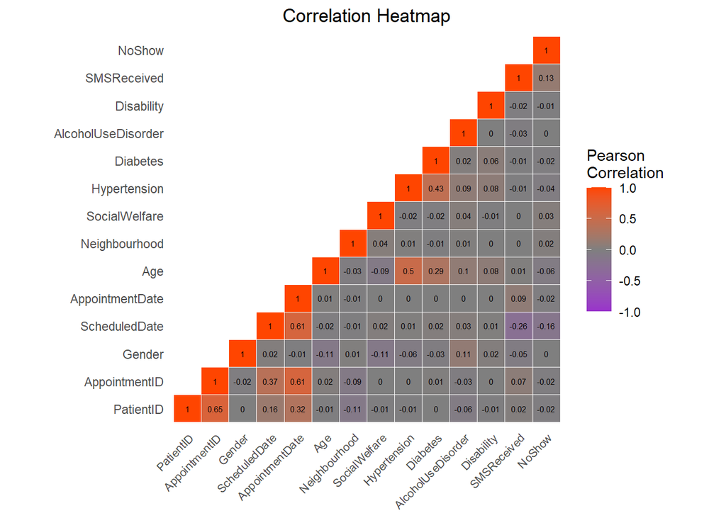

```r
# let's define a plotting function
corplot = function(df){

  cor_matrix_raw <- round(cor(df),2)
  cor_matrix <- melt(cor_matrix_raw)


  #Get triangle of the correlation matrix
  #Lower Triangle
  get_lower_tri<-function(cor_matrix_raw){
    cor_matrix_raw[upper.tri(cor_matrix_raw)] <- NA
    return(cor_matrix_raw)
  }

  # Upper Triangle
  get_upper_tri <- function(cor_matrix_raw){
    cor_matrix_raw[lower.tri(cor_matrix_raw)]<- NA
    return(cor_matrix_raw)
  }

  upper_tri <- get_upper_tri(cor_matrix_raw)

  # Melt the correlation matrix
  cor_matrix <- melt(upper_tri, na.rm = TRUE)

  # Heatmap Plot
  cor_graph <- ggplot(data = cor_matrix, aes(Var2, Var1, fill = value))+
    geom_tile(color = "white")+
    scale_fill_gradient2(low = "darkorchid", high = "orangered", mid = "grey50",
                         midpoint = 0, limit = c(-1,1), space = "Lab",
                         name="Pearson\nCorrelation") +
    theme_minimal()+
    theme(axis.text.x = element_text(angle = 45, vjust = 1,
                                     size = 8, hjust = 1))+
    coord_fixed()+ geom_text(aes(Var2, Var1, label = value), color = "black", size = 2) +
    theme(
      axis.title.x = element_blank(),
      axis.title.y = element_blank(),
      panel.grid.major = element_blank(),
      panel.border = element_blank(),
      panel.background = element_blank(),
      axis.ticks = element_blank())+
      ggtitle("Correlation Heatmap")+
      theme(plot.title = element_text(hjust = 0.5))

  cor_graph
}

numeric.data = mutate_all(raw.data, function(x) as.numeric(x))

# Plot Correlation Heatmap
corplot(numeric.data)
```

Correlation heatmaps are useful for identifying linear relationships between variables/features. In this case, we are particularly interested in relationships between NoShow and any specific variables.

#### Are there any other variables which strongly correlate with one another?

Yes, there are other interesting correlations to explore in the heatmap:

Negative Correlations:

1. Age and Neighbourhood: Younger people might be clustered in certain neighborhoods.

#### Do you see any issues with PatientID/AppointmentID being included in this plot?

Let’s look at some individual variables and their relationship with NoShow.

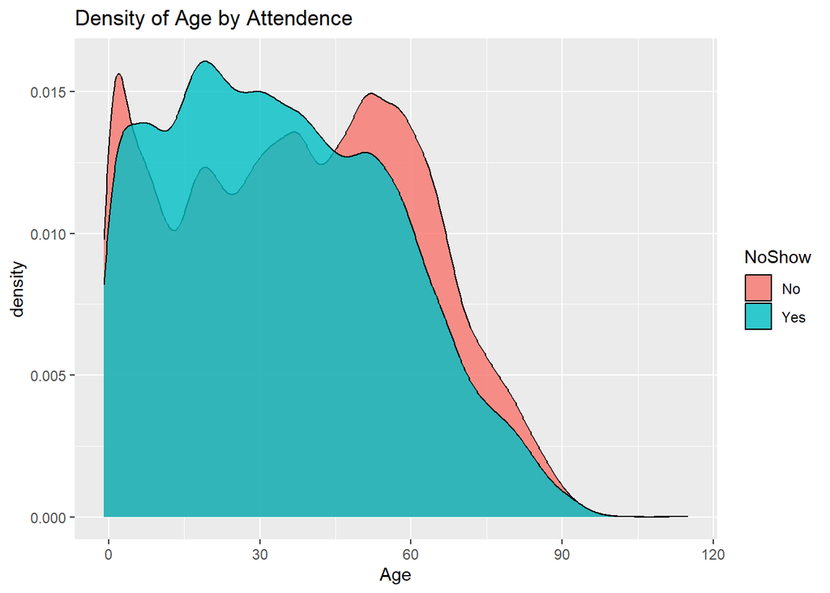

```r
ggplot(raw.data) +
  geom_density(aes(x=Age, fill=NoShow), alpha=0.8) +
  ggtitle("Density of Age by Attendence")
```

There does seem to be a difference in the distribution of ages of people that miss and don’t miss appointments. However, the shape of this distribution means the actual correlation is near 0 in the heatmap above. This highlights the need to look at individual variables.

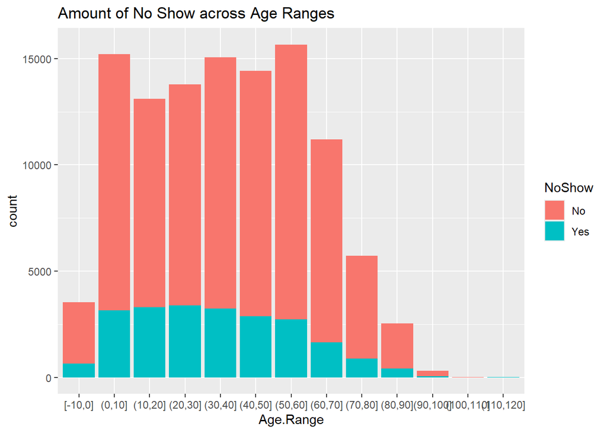

```r
raw.data <- raw.data %>% mutate(Age.Range=cut_interval(Age, length=10))

ggplot(raw.data) +
  geom_bar(aes(x=Age.Range, fill=NoShow)) +
  ggtitle("Amount of No Show across Age Ranges")
```

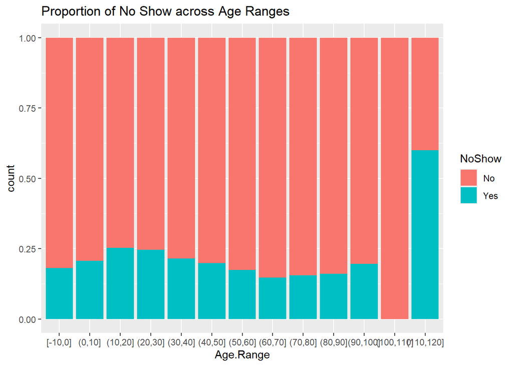

```r
ggplot(raw.data) +
  geom_bar(aes(x=Age.Range, fill=NoShow), position='fill') +
  ggtitle("Proportion of No Show across Age Ranges")
```

#### How could you be misled if you only plotted 1 of these 2 plots of attendance by age group?

Here’s how we could be misled if we only plotted one of the two plots (density plot vs. proportion by age range) when analyzing attendance by age group:

Misinterpretation with Density Plot:

If we only analyzed the density plot, we might incorrectly assume there’s no significant relationship between age and no-show rates. This is because the correlation coefficient in the heatmap might be close to zero, even though the density plot visually shows some separation between the distributions of ages for patients who show and those who don’t. The density plot focuses on the overall distribution of the data, and it might not capture non-linear relationships or how the risk of no-shows changes across different age groups.

Misinterpretation with Proportion Plot:

On the other hand, if we only analyzed the proportion by age range plot (bar chart with stacked bars), we might miss some subtleties in the data. This plot focuses on the relative risk within each age group, but it doesn’t reveal the overall shape of the age distribution for patients who show or don’t show. It’s possible that a specific age group has a higher proportion of no-shows, but the overall number of patients in that age group might be relatively small compared to other groups.

The key takeaway from this is that number of individuals > 90 are very few from plot 1 so probably are very small so unlikely to make much of an impact on the overall distributions. However, other patterns do emerge such as 10-20 age group is nearly twice as likely to miss appointments as the 60-70 years old.

Next, we’ll have a look at SMSReceived variable:

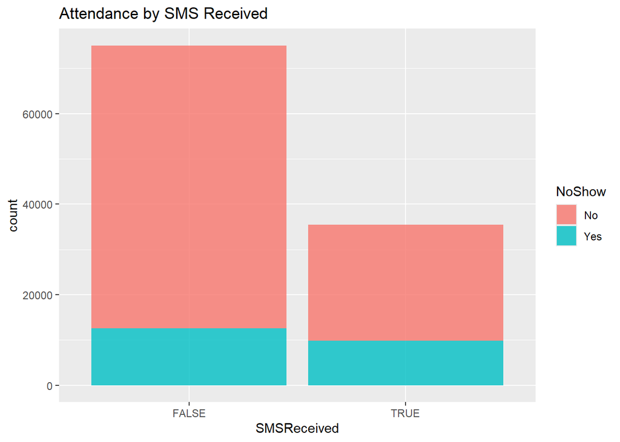

```r
ggplot(raw.data) +
  geom_bar(aes(x=SMSReceived, fill=NoShow), alpha=0.8) +
  ggtitle("Attendance by SMS Received")
```

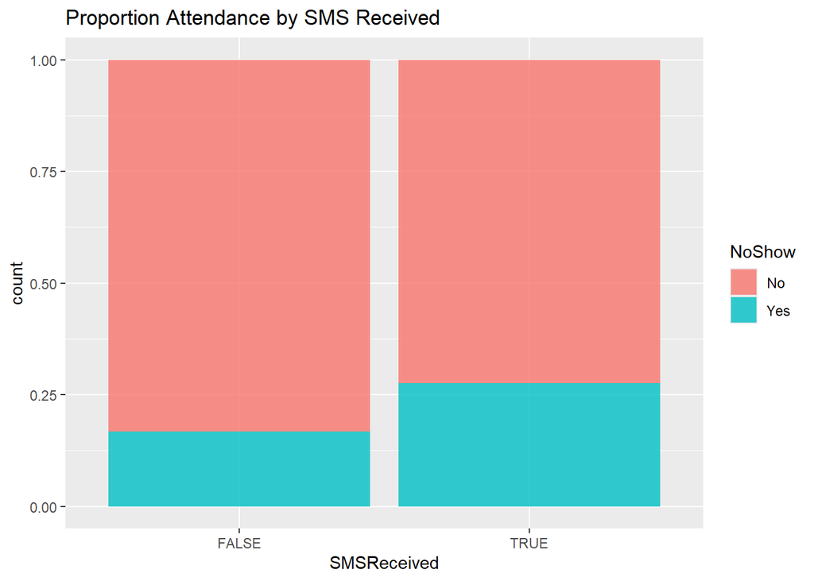

```r
ggplot(raw.data) +
  geom_bar(aes(x=SMSReceived, fill=NoShow), position='fill', alpha=0.8) +
  ggtitle("Proportion Attendance by SMS Received")
```

#### From this plot does it look like SMS reminders increase or decrease the chance of someone not attending an appointment? Why might the opposite actually be true (hint: think about biases)?

Reasons Why the Contrary May Be True (Bias):

#### Create a similar plot which compares the the density of NoShow across the values of disability

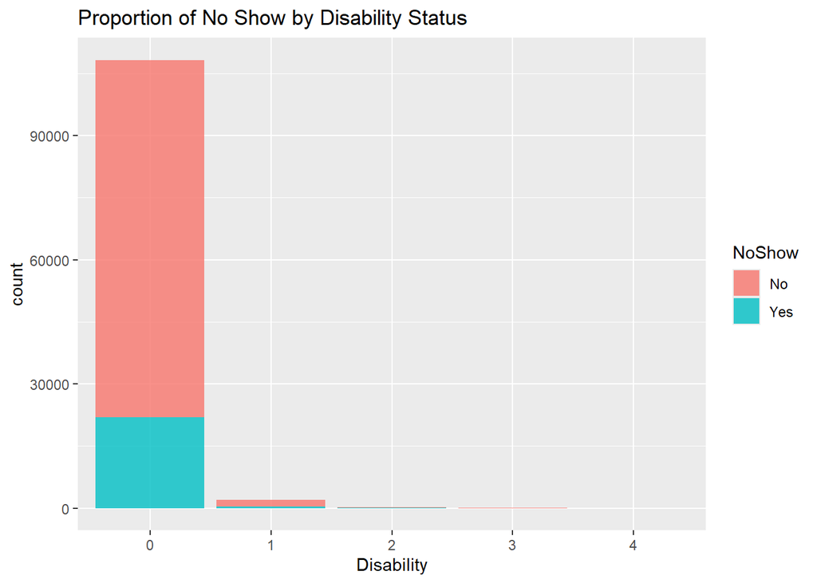

```r
ggplot(raw.data) +
  geom_bar(aes(x = Disability, fill = NoShow), alpha = 0.8) +
  ggtitle("Proportion of No Show by Disability Status")
```

Now let’s look at the neighbourhood data as location can correlate highly with many social determinants of health.

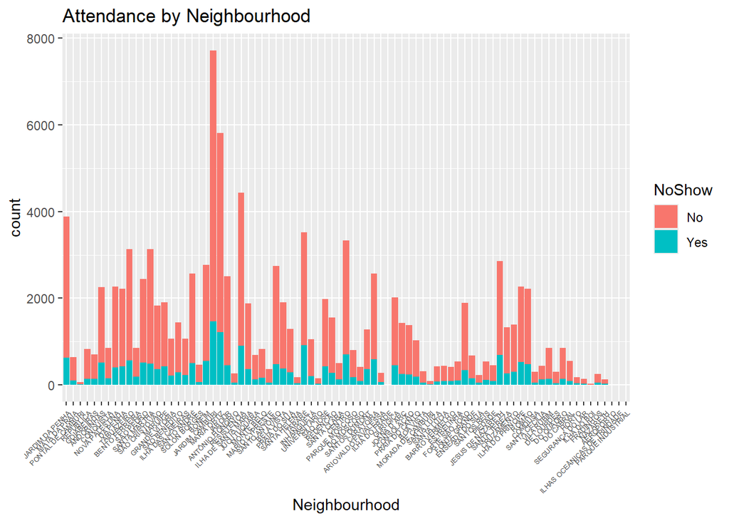

```r
ggplot(raw.data) +
  geom_bar(aes(x=Neighbourhood, fill=NoShow)) +
  theme(axis.text.x = element_text(angle=45, hjust=1, size=5)) +
  ggtitle('Attendance by Neighbourhood')
```

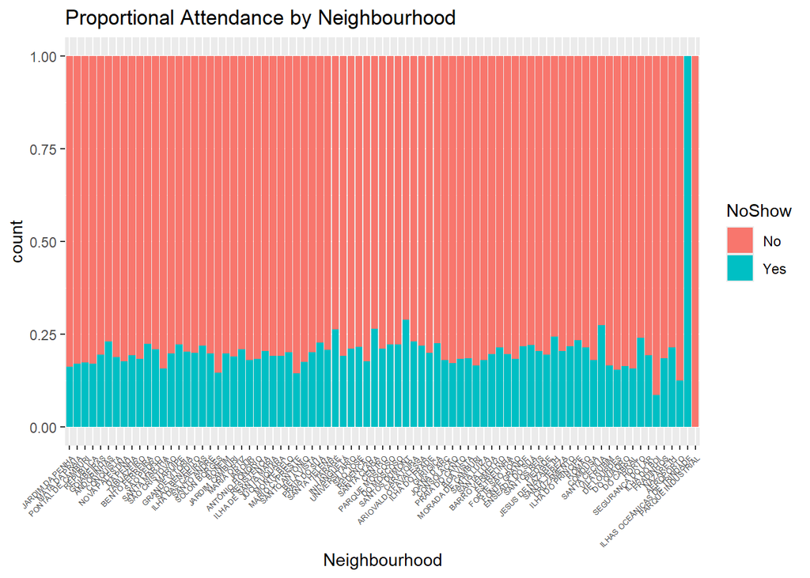

```r
ggplot(raw.data) +
  geom_bar(aes(x=Neighbourhood, fill=NoShow), position='fill') +
  theme(axis.text.x = element_text(angle=45, hjust=1, size=5)) +
  ggtitle('Proportional Attendance by Neighbourhood')
```

Most neighborhoods have similar proportions of no-show but some have much higher and lower rates.

#### Suggest a reason for differences in attendance rates across neighbourhoods.

There exist multiple plausible explanations for the variations in attendance rates among different neighbourhoods:

1. Social Determinants of Health: A neighborhood’s social determinants of health, which include housing quality, education level, poverty, and access to transportation, can differ greatly. Each of these elements may have an impact on a person’s capacity or drive to keep appointments. For instance, people living in low-income areas might find it difficult to pay for childcare options that would enable them to attend, or they might not have as many options for transportation to appointments.
2. Healthcare Accessibility: The accessibility and availability of medical facilities may also be important. Higher no-show rates may be observed in neighbourhoods with limited access to healthcare (e.g., lengthy wait times, inconvenient clinic hours).
3. Community Trust: There are differences in neighbourhood trust in the healthcare system. Lower attendance rates may result from past bad experiences with healthcare providers in some communities.

Now let’s explore the relationship between gender and NoShow.

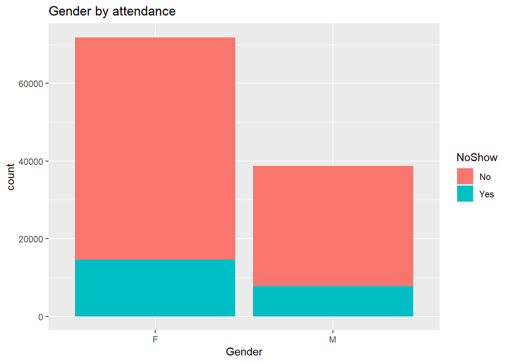

```r
ggplot(raw.data) +
  geom_bar(aes(x=Gender, fill=NoShow))+
  ggtitle("Gender by attendance")
```

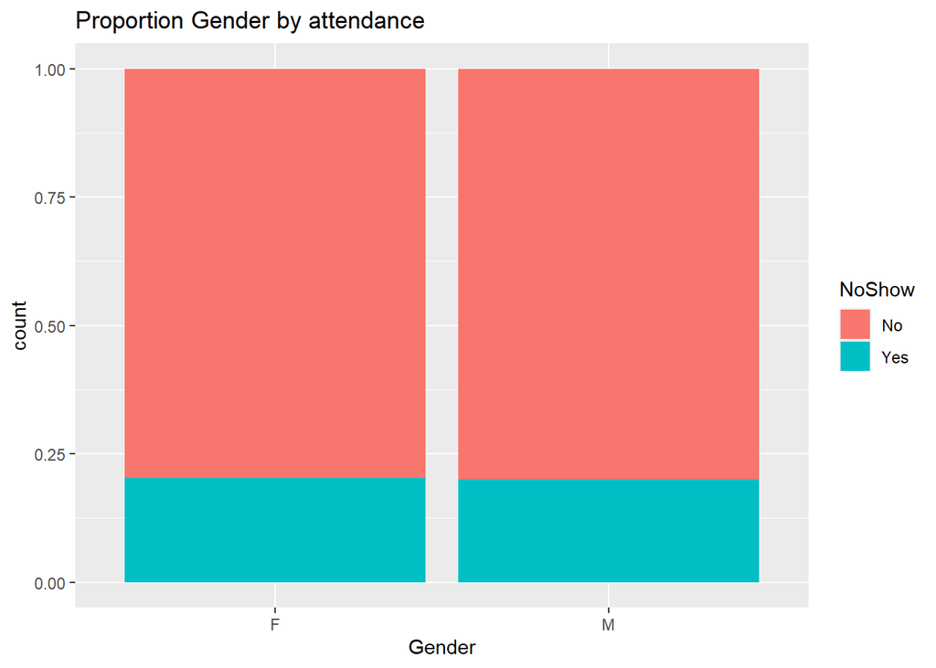

```r
ggplot(raw.data) +
  geom_bar(aes(x=Gender, fill=NoShow), position='fill')+
  ggtitle("Proportion Gender by attendance")
```

#### Create a similar plot using SocialWelfare

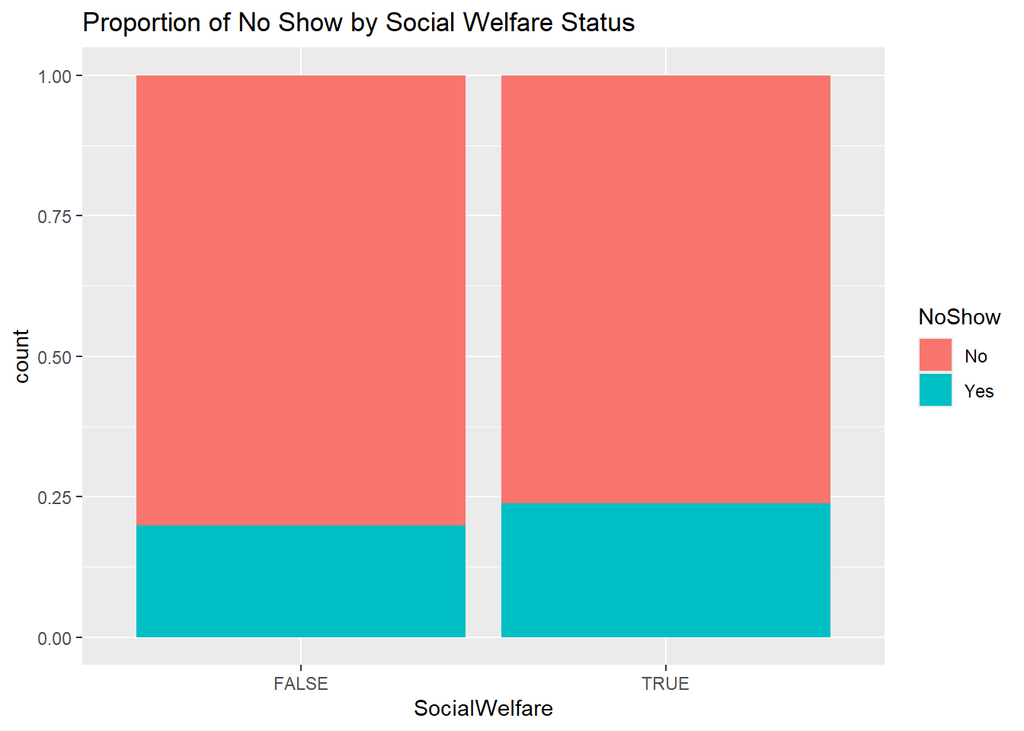

```r
ggplot(raw.data) +
  geom_bar(aes(x = SocialWelfare, fill = NoShow), position = 'fill') +
  ggtitle("Proportion of No Show by Social Welfare Status")
```

Far more exploration could still be done, including dimensionality reduction approaches but although we have found some patterns there is no major/striking patterns on the data as it currently stands.

However, maybe we can generate some new features/variables that more strongly relate to the NoShow.

Feature Engineering Let’s begin by seeing if appointments on any day of the week has more no-show’s. Fortunately, the lubridate library makes this quite easy!

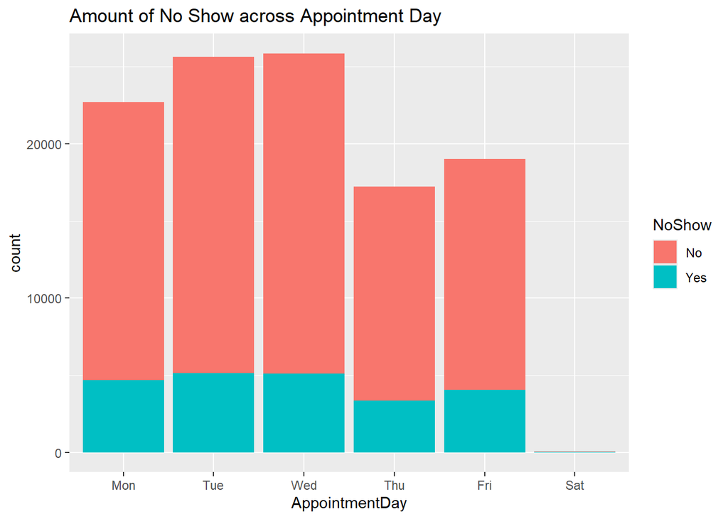

```r
raw.data <- raw.data %>% mutate(AppointmentDay = wday(AppointmentDate, label=TRUE, abbr=TRUE),
                                 ScheduledDay = wday(ScheduledDate,  label=TRUE, abbr=TRUE))

ggplot(raw.data) +
  geom_bar(aes(x=AppointmentDay, fill=NoShow)) +
  ggtitle("Amount of No Show across Appointment Day")
```

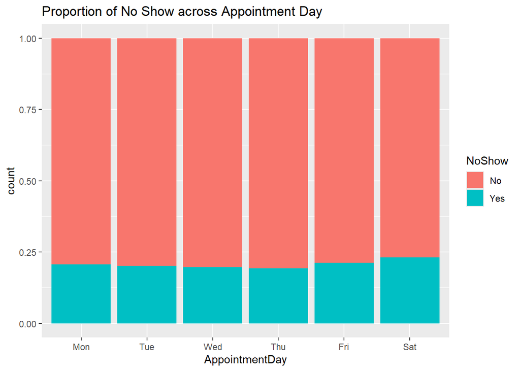

```r
ggplot(raw.data) +
  geom_bar(aes(x=AppointmentDay, fill=NoShow), position = 'fill') +
  ggtitle("Proportion of No Show across Appointment Day")
```

```
## Defaulting to continuous.
```

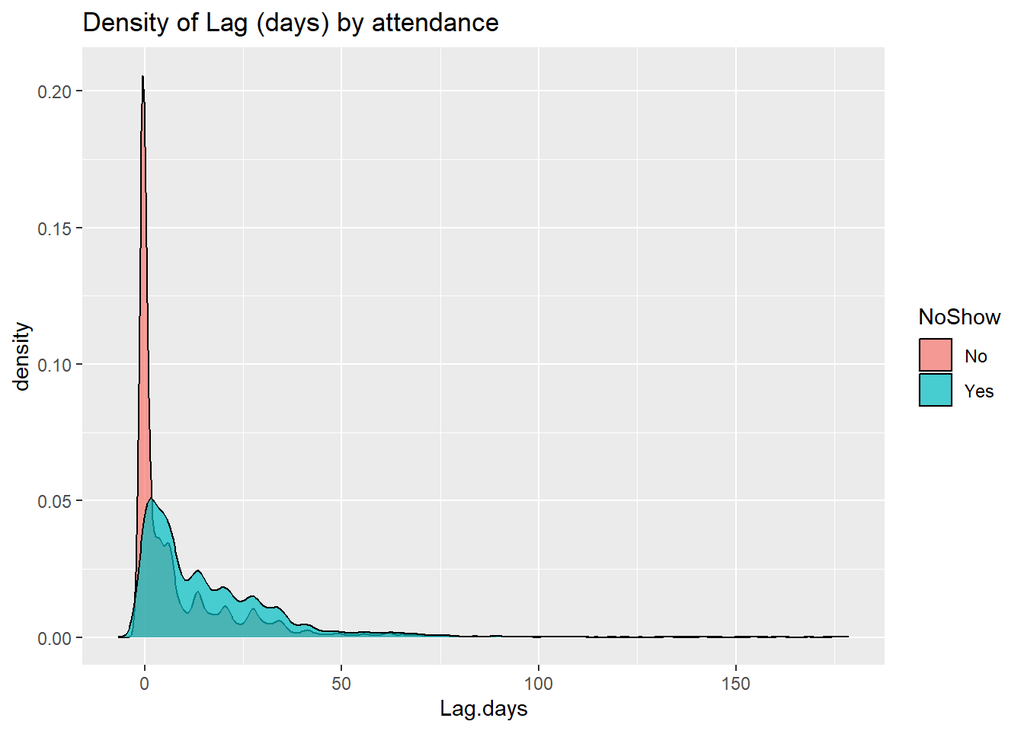

```r
raw.data <- raw.data %>% mutate(Lag.days=difftime(AppointmentDate, ScheduledDate, units = "days"),
                                Lag.hours=difftime(AppointmentDate, ScheduledDate, units = "hours"))

ggplot(raw.data) +
  geom_density(aes(x=Lag.days, fill=NoShow), alpha=0.7)+
  ggtitle("Density of Lag (days) by attendance")
```

#### Have a look at the values in lag variable, does anything seem odd?

It’s difficult to definitively say if there’s something odd about the values in the lag variables (Lag.days and Lag.hours) without seeing the actual data distribution. However, here are some things to consider:

Negative Lag Values: In theory, the lag between the appointment date and the scheduled date shouldn’t be negative. A negative lag would imply the appointment happened before it was scheduled. There could be a few reasons for this:

Data Entry Errors: Data entry mistakes during appointment scheduling or data collection could lead to negative lag values. Date/Time Format Issues: Inconsistent date/time formating might cause calculations to produce negative lags. Extremely Large Lag Values: While large positive lags (long delays between scheduled and actual appointments) are possible, extremely large values (e.g., months or years) might indicate errors. These could be due to:

Data Cleaning Issues: Missing or incorrect scheduled dates could lead to very large lags when compared to the actual appointment date. Cancelled Appointments: Appointments that were cancelled far in advance might still be in the data set, resulting in an inflated lag if the cancellation date wasn’t recorded.

### Predictive Modeling

Let’s see how well we can predict NoShow from the data.

```r
### REMOVE SUBSAMPLING FOR FINAL MODEL
data.prep <- raw.data %>% select(-AppointmentID, -PatientID) #%>% sample_n(10000)

set.seed(42)
data.split <- initial_split(data.prep, prop = 0.7)
train  <- training(data.split)
test <- testing(data.split)
```

Let’s now set the cross validation parameters, and add classProbs so we can use AUC as a metric for xgboost.

```r
fit.control <- trainControl(method="cv",number=3,
                           classProbs = TRUE, summaryFunction = twoClassSummary)
```

#### Based on the EDA, how well do you think this is going to work?

We’ve done some exploratory data analysis (EDA), and based on that, I think the predictive model for no-shows will probably work rather well—not remarkably. Age groupings and SMS reminders are two patterns and correlations that the EDA has found to be somewhat predictive of no-shows. The dataset might be lacking some important contextual data, such as the kind of medical appointments or more specific socioeconomic characteristics, which could enhance the predictions, yet the correlations aren’t particularly significant. Furthermore, the dataset may not be flawless given the existence of some outliers and potential problems with the quality of the data (such as ages that are unlikely). Therefore, without additional data and refining, the model is unlikely to be particularly accurate, even though it should be able to generate helpful predictions.

Now we can train our XGBoost model

```r
xgb.grid <- expand.grid(eta=c(0.05),
                       max_depth=c(4),colsample_bytree=1,
                       subsample=1, nrounds=500, gamma=0, min_child_weight=5)

xgb.model <- train(NoShow ~ .,data=train, method="xgbTree",metric="ROC",
                  tuneGrid=xgb.grid, trControl=fit.control)

xgb.pred <- predict(xgb.model, newdata=test)
xgb.probs <- predict(xgb.model, newdata=test, type="prob")
```

```r
test <- test %>% mutate(NoShow.numerical = ifelse(NoShow=="Yes",1,0))
confusionMatrix(xgb.pred, test$NoShow, positive="Yes")
```

```
## Confusion Matrix and Statistics
##
##           Reference
## Prediction    No   Yes
##        No  26385  6390
##        Yes   142   242
##
##                Accuracy : 0.803
##                  95% CI : (0.7987, 0.8073)
##     No Information Rate : 0.8
##     P-Value [Acc > NIR] : 0.08578
##
##                   Kappa : 0.0481
##
##  Mcnemar's Test P-Value : < 2e-16
##
##             Sensitivity : 0.036490
##             Specificity : 0.994647
##          Pos Pred Value : 0.630208
##          Neg Pred Value : 0.805034
##              Prevalence : 0.200006
##          Detection Rate : 0.007298
##    Detection Prevalence : 0.011581
##       Balanced Accuracy : 0.515568
##
##        'Positive' Class : Yes
##
```

```r
paste("XGBoost Area under ROC Curve: ", round(auc(test$NoShow.numerical, xgb.probs[,2]),3), sep="")
```

```
## [1] "XGBoost Area under ROC Curve: 0.74"
```

This isn’t an unreasonable performance, but let’s look a bit more carefully at the correct and incorrect predictions,

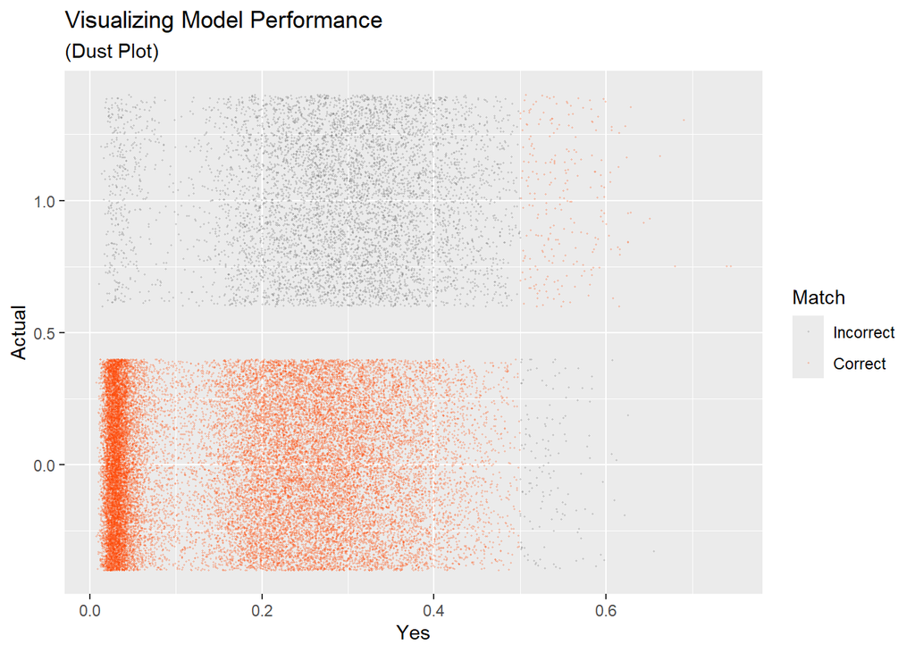

```r
xgb.probs$Actual = test$NoShow.numerical
xgb.probs$ActualClass = test$NoShow
xgb.probs$PredictedClass = xgb.pred
xgb.probs$Match = ifelse(xgb.probs$ActualClass == xgb.probs$PredictedClass,
                         "Correct","Incorrect")
# [4.8] Plot Accuracy
xgb.probs$Match = factor(xgb.probs$Match,levels=c("Incorrect","Correct"))
ggplot(xgb.probs,aes(x=Yes,y=Actual,color=Match))+
  geom_jitter(alpha=0.2,size=0.25)+
  scale_color_manual(values=c("grey40","orangered"))+
  ggtitle("Visualizing Model Performance", "(Dust Plot)")
```

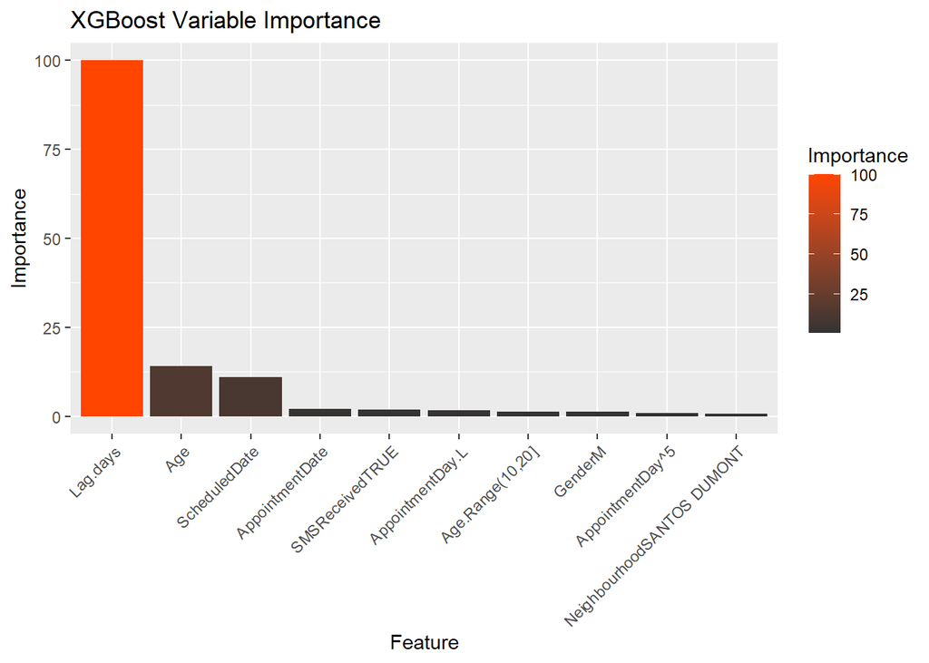

```r
results = data.frame(Feature = rownames(varImp(xgb.model)$importance)[1:10],
                     Importance = varImp(xgb.model)$importance[1:10,])

results$Feature = factor(results$Feature,levels=results$Feature)


# [4.10] Plot Variable Importance
ggplot(results, aes(x=Feature, y=Importance,fill=Importance))+
  geom_bar(stat="identity")+
  scale_fill_gradient(low="grey20",high="orangered")+
  ggtitle("XGBoost Variable Importance")+
  theme(axis.text.x = element_text(angle = 45, hjust = 1))
```

#### Trying for Random Forest using caret package

```r
data.prep <- raw.data %>% select(-AppointmentID, -PatientID) %>% sample_n(10000)

# Split the data
set.seed(42)
data.split <- initial_split(data.prep, prop = 0.7)
train  <- training(data.split)
test <- testing(data.split)
```

```r
library(caret)
library(randomForest)
library(doParallel)
library(pROC)

# Set up parallel processing
cl <- makeCluster(detectCores() - 1) # leave one core free
registerDoParallel(cl)

fit.control <- trainControl(method = "cv", number = 3,
                            classProbs = TRUE, summaryFunction = twoClassSummary)

rf.model <- train(NoShow ~ ., data = train, method = "rf",
                  metric = "ROC", trControl = fit.control,
                  ntree = 100)

# Stop parallel processing
stopCluster(cl)
registerDoSEQ()

rf.pred <- predict(rf.model, newdata = test)
rf.probs <- predict(rf.model, newdata = test, type = "prob")

test <- test %>% mutate(NoShow.numerical = ifelse(NoShow == "Yes", 1, 0))
confusionMatrix(rf.pred, test$NoShow, positive = "Yes")
```

```
## Confusion Matrix and Statistics
##
##           Reference
## Prediction   No  Yes
##        No  2330  538
##        Yes   83   49
##
##                Accuracy : 0.793
##                  95% CI : (0.7781, 0.8074)
##     No Information Rate : 0.8043
##     P-Value [Acc > NIR] : 0.943
##
##                   Kappa : 0.0694
##
##  Mcnemar's Test P-Value : <2e-16
##
##             Sensitivity : 0.08348
##             Specificity : 0.96560
##          Pos Pred Value : 0.37121
##          Neg Pred Value : 0.81241
##              Prevalence : 0.19567
##          Detection Rate : 0.01633
##    Detection Prevalence : 0.04400
##       Balanced Accuracy : 0.52454
##
##        'Positive' Class : Yes
##
```

```r
auc_value <- auc(test$NoShow.numerical, rf.probs[,2])
```

```r
paste("Random Forest Area under ROC Curve: ", round(auc_value, 3), sep = "")
```

```
## [1] "Random Forest Area under ROC Curve: 0.707"
```

#### Based on everything, do you think we can trust analyses based on this dataset? Explain your reasoning

While the analysis seems to have been conducted carefully, there are some reasons to hold off on completely trusting this dataset for no-show predictions. Here’s the breakdown:

Sure, the data prep looks good. They removed unnecessary columns and split things up for training and testing. Using cross-validation is a plus, making sure the model isn’t just memorizing a specific data pattern.

But dig a bit deeper. The key metrics, like the AUC, aren’t stellar. It performs just okay at differentiating no-shows from those who show up. The confusion matrix highlights this too – it catches some no-shows, but misses a bunch.

Imagine a security system that lets most burglars walk right in. Not ideal. In this case, the model might miss a significant number of patients who actually won’t show up, causing scheduling problems and resource allocation issues.

So, the analysis seems thorough, but the model’s performance itself raises some concerns. Trusting this dataset completely for no-show prediction might be risky until we investigate these issues further.